# ReportSummary

-YY-

6/22/2022

# Ad-valorem equivalent estimates of digital-trade regulatory measures

## Abstract

Applied researchers increasingly look to measure the effect of non-tariff measures (NTM) on international trade. This requires their quantification, which is a non-trivial and often controversial estimation task involving heavy computation at the disaggregated levels. In this paper, we use a price-based approach to estimate GTAP sector-specific ad-valorem equivalents (AVE) of digital-trade regulatory measures at the HS six-digit level by using HS-GTAP sector concordance and HS six-digit level bilateral trade flows as weights. The derived AVEs estimated are importer specific, which rely on scores of digital-trade regulatory measures from ESCAP-OECD initiative on digital trade regulatory analysis.

# Introduction

Over the past two decades, thanks to multilateralism, regional trade agreements as well as unilateral efforts, global applied tariffs have been more than halved. At the same time, however, the number of non-tariff measures (NTMs) as evident by the growing number of new notifications to the WTO, and including digital-trade regulatory measures, has risen significantly. In many developing countries, digital-economic integration through digital trade has been identified as a key priority for sustainable growth in the 21st century. Hence, in this paper, we look into digital-trade regulatory measures affecting international trade; More specifically, we use a price-based approach to estimate GTAP sector-specific ad-valorem equivalents (AVEs) of digital-trade regulatory measures for 22 countries whose digital-trade regulations are captured by ESCAP’s Regional Digital Trade Integration Index (RDTII).

In the literature, estimation of ad-valorem-equivalents (AVEs) of non-tariff measures (NTMs) are generally conducted using one of two approaches: price-based or quantity-based. In this paper, we adopt the price-based estimation based primarily on the work of Cadot and co-authors, e.g. (Cadot and Gourdon 2015; Cadot et al. 2015; Cadot, Gourdon, and Tongeren 2018; Cadot and Ing 2017)), as this procedure allows direct use in the GTAP model. That is, because quantity-based estimation requires values of import demand elasticities, which, if different to those used in GTAP model, results in inconsistencies will result in erroneous output, price-based estimations are more straightforward and it is not necessary to adjust the derived AVE estimates to be used in the GTAP model.

# Digital-trade regulatory measures (RDTII)

This study relies heavily on the work done by ESCAP’s Regional Digital Trade Integration Index (RDTII) that quantifies digital-trade regulation covering regulatory status and policy stance as of June 2021 for 22 Asia-Pacific economies; namely, Australia, Brunei Darussalam, China, Cambodia, India, Indonesia, Japan, Kazakhstan, Lao P.D.R, Malaysia, Nepal, New Zealand, Pakistan, Philippines, Republic of Korea, Russian Federation, Singapore, Thailand, Turkey, Vanuatu, Viet Nam, and Hong Kong.

The RDTII database covers regulatory measures in the following areas, or what we refer to as Pillars:

**(Pillar1)** Trade-policy measures affecting trade in digital goods: This captures tariffs, trade defense measures affecting trade in ICT-related goods. It also looks at the commitment to the WTO Information Technology Agreement (ITA) of 1996 (ITA I) and its expansion in 2015 (ITA II), the Ministerial Declaration on the Expansion of Trade in Information Technology Products.

**(Pillar2)** Public procurement related to digital goods and services. This captures explicit and implicit discriminations in the procurement process and the commitment to the WTO Government Procurement Agreement (GPA). It also captures the requirement to surrender source codes or to use specific encryption standards to participate in tenders.

**(Pillar3)** Regulations on foreign investment in sectors considered relevant for the digital economy. This captures regulations and conditions which affect foreign investment in services and are considered relevant for the digital economy: the telecommunication services, computer services, internet publishing services, manufacturing of telecommunication facilities, and e-commerce. It also considers regulatory procedures to register a company, discriminatory treatment relating to acquisition and use of land and real estate, licensing, taxes, and subsidies.

**(Pillar4)** Intellectual property rights. This considers whether a country has put in place administrative or juridical procedures to enforce intellectual property rights, particularly copyrights and trademarks, application process of patents, regulations prohibiting the unlawful acquisition, commercial use, or disclosure of a firm’s confidential information.

**(Pillar5)** Infrastructure, connectivity and competition. This captures the state deregulation of the telecommunications market, fees, and conditions for interconnections, licensing requirements, and infrastructure readiness such as network coverage, internet bandwidth, and secure internet servers. It also considers procedures to regulate anti-competitive practices in telecommunication and computer services sectors, including right of appeal to decisions made by the regulatory body, channels to redress when affected by business practices and exclusion of publicly-controlled firms from the general competition law.

**(Pillar6)** Cross-border data flows. The database captures regulations governing the cross-border transfer of personal and non-personal data, requirements to store and/or process data locally, and conditional flow regime.

**(Pillar7)** Domestic data policies. This captures regulations that apply to the use of data domestically, including data protection, data retention, requirement to appoint data protection impact assessment and/or data protection officer, and whether the government will follow the same procedures when accessing personal data online and offline.

**(Pillar8)** Intermediary liability and limitations on access to commercial content. The database captures requirements that intermediaries between content producers and internet users are requested to fulfill, a safe harbor regime as well as a monitoring requirement. It also considers requirements to provide digital services and limitations on access to commercial internet content, including blocking, filtering or limiting on download and streaming.

**(Pillar9)** Quantitative trade restrictions on digital goods. This captures quantitative import restrictions, local content requirements for the commercial market, and export restrictions of ICT goods and digital services.

**(Pillar10)** Regulatory transparency and technical standards on digital goods and services. This captures the transparency of regulatory regimes and standards, adequate communication to the public, including foreign suppliers, and the use of internationally recognized encryption standards. It captures self-certification for product safety, along with measures on product screening and testing requirements.

**(Pillar11)** Electronic transactions, payment and consumer protection. This captures regulations that affect online sales and electronic transactions, including the cross-border provision of services (Mode 1), commercial and local presence requirements, a threshold for the De Minimis rule, a legal framework and security standards for online consumer protection, regulations affecting the use of electronic payments; credit card services; electronic signature; dispute settlement mechanism, and deviation from international standards.

The RDTII overall scores (which are averages of the pillar scores, each ranging from 0 to 1 – no regulation to maximum) are shown in the figure below; New Zealand has the lowest score of 0.18 while China has the highest of 0.796.

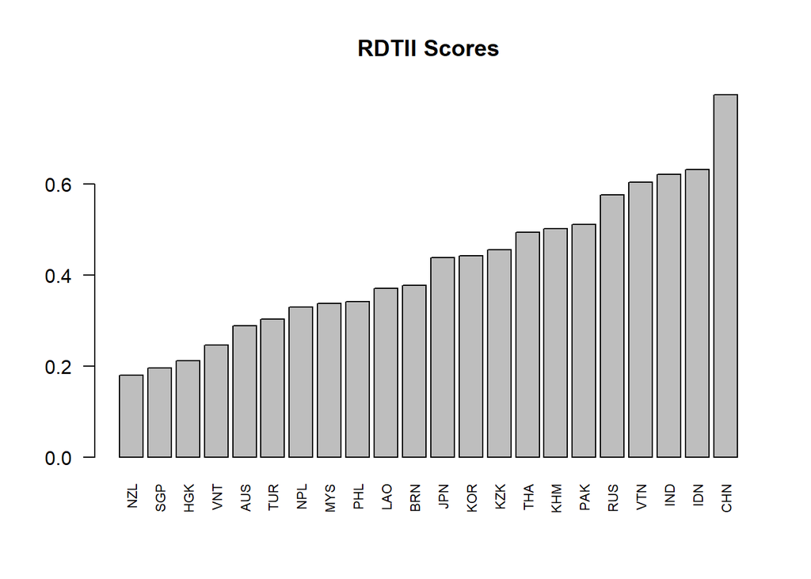

```r
RDTII <- RDTII_raw$RDTII
names(RDTII) <- RDTII_raw$Country
barplot(RDTII, # Modify x-axis labels
        las = 2,
        cex.names = 0.7,
        main ="RDTII Scores")
```

```r
library(dplyr)
```

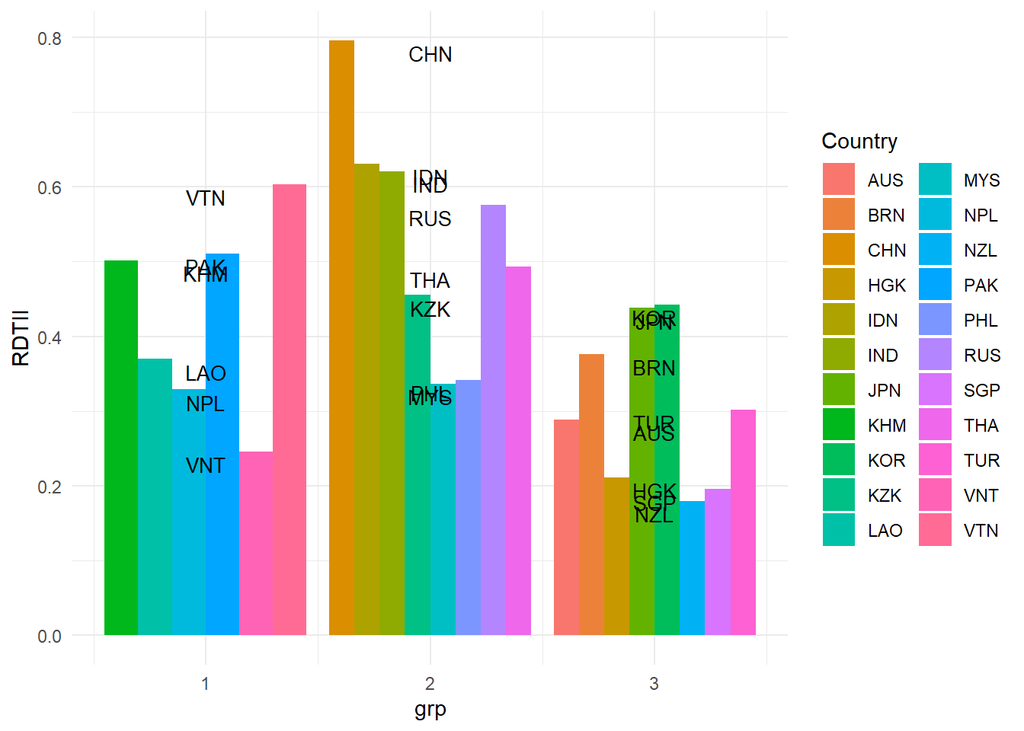

```r
RDTII_raw <- RDTII_raw[order(RDTII_raw$Country),]

RDTII_raw$names <- c("Australia", "Brunei", "China", "Hong Kong", "India", "Indonesia", "Japan", "Cambodia",
   "Korea, Rep.", "Kazakhstan", "Lao", "Malaysia", "Nepal", "New Zealand", "Pakistan",
   "Phillipines", "Russia", "Singapore", "Thailand", "Turkey", "Vietnam", "Vanuatu")
RDTII_raw$grp <- c(3, 3, 2, 3, 2, 2, 3, 1, 3, 2, 1, 2, 1, 3, 1, 2, 2, 3, 2, 3, 1, 1)

# RDTII_raw<-reporter.aves[!(reporter.aves$ave_weighted=="NaN"),]

library(ggplot2)

ggplot(data = RDTII_raw, aes(x = grp, y = RDTII, fill = Country)) +
    geom_bar(stat="identity", position ="dodge") +
    geom_text(aes(label= Country), vjust= 1.3, size=3.5) +
    theme_minimal()
```

It is worth noting that these digital-trade regulations are in fact national regulations, and as such, are the only true comprehensive sources of policy regulations that could “potentially have an economic effect on international trade in goods, changing quantities traded, or prices or both” as they are part of the national repositories of legislative acts.

## Summary of other data

Unit values of bilateral import flows, a proxy for import prices, are obtained at the six-digit Harmonised System (HS) level by dividing trade values by respective quantities. Trade data was sourced from the World Bank’s World Integrated Trade Solution (WITS) platform for the latest year.

Since not all recorded bilateral import flows contained quantity information, records with missing quantity information were omitted. Furthermore, in some instance different countries reported different quantity types for the same HS6 codes (for example, kg vs number of items – see COMTRADE methodological note). In such cases, records with the majority type of quantity types were retained, with the minority types further truncated from the analysis. Furthermore, due to different methodologies used (in terms of reporting quantities) or erroneous data entry, some prices were evident outliers, and, the top 5% of top derived price values were removed.

To control for the effects of tariffs, simple average tariff data is used, which is obtained at HS six-digit level (HS 2012 classification) from the World Bank’s WITS platform and the WTO tariff download facility.[^1] Furthermore, the usual standard gravity variables were used; bilateral distance, contiguity, landlockedness, and common language are obtained from Mayer and Zignago (2011),[^2] while data on the presence of regional trade agreements (RTAs) data is acquired from Sousa (2012), with the latest trade agreementdata expanded up to 2015.

# Method for AVE estimation on digital-trade regulatory measures

## (A) Previous empirical literature

As to our knowledge there are no papers as yet attempting to quantify AVEs of digital-trade regulatory measures. We however follow the empirical work carried out on ad-valorem-equivalents (AVEs) of NTMs, which can be classified into two approached: (1) quantity-based approach (Kee, Nicita, and Olarreaga (2006); Kee and Nicita (2016)) or (2) price-based approach (Cadot, Gourdon, and Tongeren (2018); Cadot et al. (2015); Cadot and Gourdon (2015); Cadot and Ing (2017)). NICITA and MELO (2018) provide a good summary of problems associated with both quantity-based and price-based approaches to the estimation of AVEs of NTMs, which still remains a daunting task mainly because of data limitations such as comprehensiveness, diversification, lack of precision, dimensionality, etc.

Reason for using interaction effects, see Cadot and Ing (2017) pg.2-3 and Kee, Nicita, and Olarreaga (2006) i.e. if interactions are not used, regression captures only average effects across countries and not individual country effects.

## (B) Method employed in this study

We employ a price-based model to observe the effect of digital-trade regulations measure by REDTII scores on prices. That is, we attempt at estimating AVEs of digital-trade regulations captured by ESCAP’s RDTII approach which identifies and quantifies regulatory restrictiveness in comprehensive policy areas that affect digital trade integration in Asia-Pacific economies.

Let indices $i, j,$ and $k$ denote importer $i$, exporter or partner country $j$, and product $k$, respectively. Let $p_{ijk}$ be the unit-value of good $k$ imported from $j$ to $i$. Furthermore let $DIG_i$ to be the average of all Pillar scores for importer $i$ imposed on all other the trade partners (i.e. rest-of-the-world), and let $tariff_{ijk}$ be the tariff rate on product $k$ imposed by importer $i$ from a trade partner $j$.

To control for country- and pair-specific characteristics, let $\delta_i$, and $\delta_j$ be importer and exporter fixed effects, respectively; Pair characteristics, $dist_{ij}$, $contig_{ij}$, $comlang_{ij}$, $landlocked_{ij}$, and $RTA_{ij}$ be distance between a pair of trading countries, contiguity (whether they share a common border), common official language, whether either is landlocked, and RTAs that importer i and exporter j share, respectively.

Due to the significant size of the underlying database (1,124,470 observations) and resultant computational capacity limitations, the models are estimated at the HS2 level (chapter). This still, however, allows for the each (chapter) regression to also include HS6 product-specific fixed effects, $\rho$.

The model specification used in this estimation is as follows:

$$\begin{align*}
\text{ln } p_{ijk} &= \alpha + \beta DIG_i + \gamma_1 \rho_k +
\gamma_2 \theta_{ij} + \gamma_3 tariff_{ijk} \\
& + \gamma_4 NTM_{ijk}^{Tech} + \gamma_5 NTM_{ijk}^{Non-Tech} +
\gamma_{6i}(NTM_{ijk}^{Tech} \times \delta_i) +
\gamma_{7i}(NTM_{ijk}^{Non-Tech} \times \delta_i) \\
& + \gamma_8 sim_{ij} + \epsilon_{ijk}
\end{align*}$$

where

| $DIG_i$ | is the average score of separate Pillar measures capturing digital-trade regulation imposed by country $i$ on all imports |
| --- | --- |
| $\rho$ | is the HS6 product fixed effects dummy variable (since regressions are estimated at chapter-level (i.e. there are **96 separate regressions**) |
| $\theta$ | is the pair characteristics (i.e. distance, contiguity, landlocked status, common language, and RTA) |
| $tariff_{ijk}$ | is the applied tariff (MFN or lowest preferential, if available) imposed by $i$ on imports of product $k$ from $j$ |
| $NTM_{ijk}^{Tech}$ | is the count of separate non-tariff measures from chapters A to C imposed by $i$ on imports of product $k$ from $j$ |
| $NTM_{ijk}^{Non-Tech}$ | is the count of separate non-tariff measures from chapters D to O imposed by $i$ on imports of product $k$ from $j$ |
| $sim_{ij}$ | is a measure of regulatory similarity of country $i$ and $j$ |
| $\delta_{i}$ | is fixed effect of country $i$ (included for interaction with $NTM$) |

Note that the coefficients depend only the importer country—i.e. the marginal AVE is not dependent on the partner or exporter economy.

Furthermore, as mentioned in Cadot and Gourdon (2015), exponential transformation in AVE calculations could lead to extremely large and uninterpretable AVEs. To address this issue, we apply a hyperbolic tangent function to limit the upper bound of AVEs to 100%, as well as to leave any AVE estimates whose values are between 0% and 100% unchanged:

$$AVE_i^{DIG}[total] =
\text{tanh}(exp(\beta_4 \times DIG_i) - 1) \times 100$$
Finally, following UNCTAD and Bank (2018), negative AVEs are replaced with zeros as the estimation does not account for positive effect of digital-trade regulation on trade costs.

The model is estimated for each chapter, comprising of a set of HS 6-digit level products, i.e. 96 regressions are performed (chapters 98 and above are omitted as products because chapters are very heterogeneous and have many missing and/or meaningless quantities). The coefficients with p-values above 0.1 are set to zero in the AVEs calculation. Finally, we acknowledge that limited sample size of some products in certain economies may raise issues of collinearity. For instance, if there is only one imported trade flow of a certain product for an economy, it is mathematically impossible to separate the effects of digital-trade regulatory measures from country-specific fixed effects. In such cases, the observations were further dropped (as opposed to recorded as zeros). This is an important point since missing AVE does not imply a zero AVE (which is either negative or not statistically significant), hence is handled in a different manner in GTAP which requires a balanced dataset.

# Empirical results

## (I) Summary of regression results

```r
library(dplyr)

dta.df <- as.data.frame(cbind(HS_2, results.A, results.B))
colnames(dta.df) <- c('HS2','n','Adj-R2', 'b_dig', 'p')

dta.df$bDig <- with(dta.df, ifelse(p > 0.1, 0, b_dig))
dta.df_ <- as.data.frame(sapply(dta.df, as.numeric))

# head(select(dta.df, -b_dig))                 # head(dta.df)

library(DT)
datatable(select(dta.df, -b_dig), filter = 'top', rownames = FALSE)
```

| HS2 | n | Adj-R2 | p | bDig |
| --- | --- | --- | --- | --- |
| 01 | 300 | 0.604971008535134 | 0.923707874427649 | 0 |
| 02 | 743 | 0.546505383112962 | 0.151815732156993 | 0 |
| 03 | 5229 | 0.466771971386243 | 0.258155312198748 | 0 |
| 04 | 1489 | 0.447465986005718 | 0.10618625538902 | 0 |
| 05 | 502 | 0.376620423039474 | 0.594077492781887 | 0 |
| 06 | 787 | 0.500036624249086 | 0.0907450521043037 | -1.3717438686702 |
| 07 | 3162 | 0.454664437999751 | 1.19835252665299e-05 | 0 |
| 08 | 3049 | 0.479595748361784 | 0.00101643726471742 | -2.05362551284562 |
| 09 | 2960 | 0.366737224894897 | 0.355900311866028 | 0 |
| 10 | 823 | 0.41477940019206 | 2.65439149174562e-08 | 0 |

[output cut: 86 more lines]

```r
dig_sig.M5 <- nrow(dta.df_[dta.df_$bDig!=0,])
dig_sig.POS.M5 <- nrow(dta.df_[dta.df_$bDig>0,])
dig_sig.NEG.M5 <- nrow(dta.df_[dta.df_$bDig<0,])
Adj_R.avg.M5 <- mean(dta.df_[['Adj-R2']])
```

When considering 96-sectors (at the HS-2 level), we find only 42 digital measure coefficients (of which 27 are positive and 15 are negative) to be significant at the 10 percent level, and the average Adjusted R-square of the regressions is 0.4218912.

### (a) AVE Digital-trade regulation

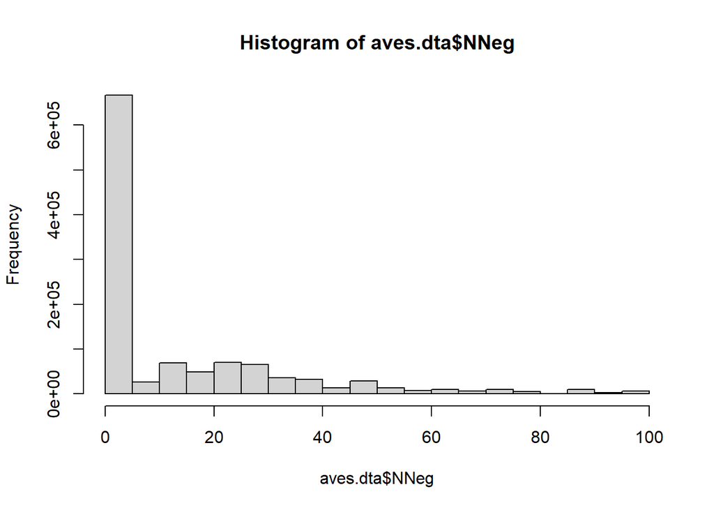

```r
aves.dta <- read.csv(paste0(path_, "aves_", model, ".csv"))
aves.dta$NNeg <- ifelse(aves.dta$aves_digital<0,0,aves.dta$aves_digital)

hist(aves.dta$NNeg)
```

The average weighted (by trade value) of non-negative AVES is 7.3482933 (note: fraction of negative AVES is 0.0862738 ; zero AVES is 0.5063093 and positive AVES is 0.4074436).

### (b) AVE Digital-trade regulation (by Country)

```r
library(dplyr)

reporter.aves <- aves.dta %>%
  group_by(reporteriso3) %>%
  summarise(ave_weighted = weighted.mean(NNeg, tradevalue, na.rm = TRUE))
# summarise(ave_mean = mean(aves.dta$POS, na.rm = TRUE))

reporter.aves$names <- c("Australia", "Brunei", "China", "Hong Kong", "India", "Indonesia", "Japan", "Cambodia",
   "Korea, Rep.", "Kazakhstan", "Lao", "Malaysia", "Nepal", "New Zealand", "Pakistan",
   "Phillipines", "Russia", "Singapore", "Thailand", "Turkey", "Vietnam", "Vanuatu")
reporter.aves$grp <- c(3, 3, 2, 3, 2, 2, 3, 1, 3, 2, 1, 2, 1, 3, 1, 2, 2, 3, 2, 3, 1, 1)
```

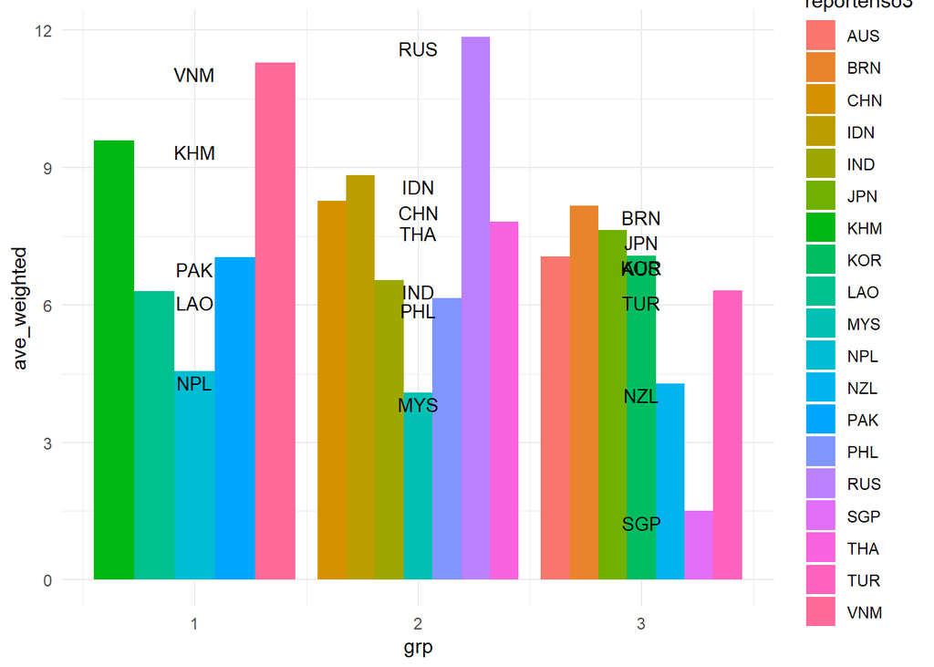

```r
library(ggplot2)

reporter.aves<-reporter.aves[!(reporter.aves$ave_weighted=="NaN"),]

ggplot(data = reporter.aves, aes(x = grp, y = ave_weighted, fill = reporteriso3)) +
    geom_bar(stat="identity", position ="dodge") +
    geom_text(aes(label= reporteriso3), vjust= 1.3, size=3.5) +
    theme_minimal()
```

(*note*): HGK, KXK and VTN are dropped.

### (c) AVE Digital-trade regulation by (Sector/Chapter/GTAP)

Please see (https://htmlpreview.github.io/?https://github.com/YongY-Github/AVES2022/blob/main/Est_A.html)